# Searching R Packages

### How to find a package that ...?

- Problem:  
  How to find what you want in the more than 10,000 packages now on CRAN and elsewhere?
- sos package  
  packageSum(findFn('your search term'))
- Rdocumentation.org
- How to combine sos and Rdocumentation?
- What would you like?  
  Beggars can be choosers  
  with modest sweat equity

### library(sos)

```r
findFn('your search term')
```

```
found 53 matches;  retrieving 3 pages
2 3
Downloaded 45 links in 31 packages.
```

This opens a page in your default browser with the results of this search.

### sos package search

- packageSum gives a summary by package

```r
yst <- findFn('your search term')
```

```
found 53 matches;  retrieving 3 pages
2 3
Downloaded 45 links in 31 packages.
```

```r
invisible(PackageSum2(yst))
```

### Other sos features

Supports

- union | and intersection & of findFn objects
- writeFindFn2xls creates an Excel file with sheets
  - packageSum
  - findFn table
  - search strategy
- Changing the sort order
  - Default “sortby” = c('Count', 'MaxScore', 'TotalScore', 'Package', 'Score', 'Function')

### Rdocumentation.org

Search all 12,412 CRAN, BioConductor and Github packages.

Search Results for your search term  
Packages 11,670 results || Functions 13,232 results

### Proposal to combine sos and Rdocumentation.org

- A web interface like the current Rdocumentation.org
  - with a dropdown menu giving options for search criteria / sort order
  - These would include options for either lexicographical or a weighted sum of different criteria (but need to keep it simple)
- Upgrade sos so it can optionally used the search criteria used by the web interface

### CRANsearcher

RStudio add-in to search CRAN packages based on keyword(s)

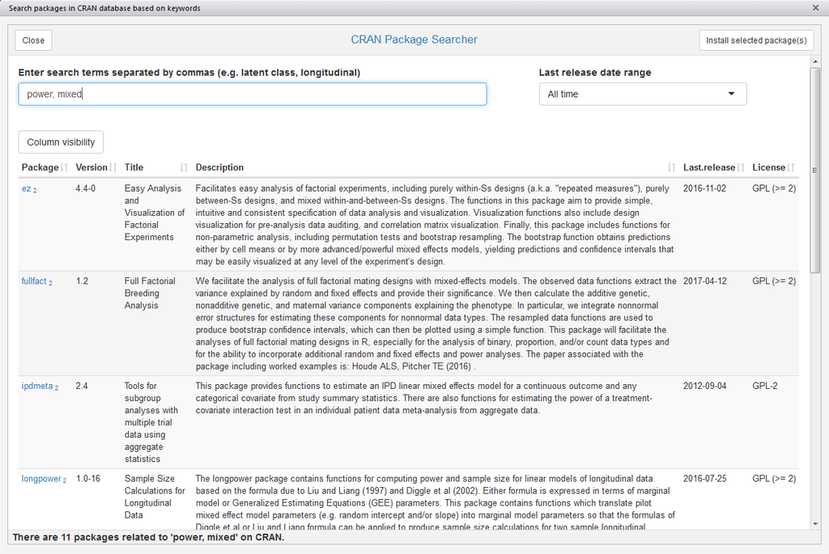

### Shortcomings of existing tools

- Web-based resources can distract away from RStudio and interrupt your workflow
- Existing tools allow search of package names, but the description is rich with information
- CRAN task views capture the highlights, but are not updated in real time

*Solution:*

- RStudio add-in tool for searching & exploring packages

### Installation & Use

- Install from CRAN

```r
# install.packages("CRANsearcher")
```

- Access from RStudio Addins drop-down
- Functionality
  - Search CRAN database based on keyword(s)
    - Searches the package name, title, and **description**
  - Filter by most recent release date
  - Link to websites to learn more
  - Install selected package(s) with the click of a button

### More information on CRANsearcher

CRAN: https://cran.r-project.org/web/packages/CRANsearcher

GitHub: https://github.com/RhoInc/CRANsearcher

Authors:

- Agustin Calatroni, Rho, Inc.
- Becca Krouse, Rho, Inc.

[figure not shown]